# Tugas Praktikum Soal Kelas 3 MPDW

# Latihan 1

Misalkan terdapat data pangsa pasar selama 20 periode dari suatu produk pasta gigi. Akan dilakukan pemodelan *distributed lag* dari pangsa pasar ($Y$) terhadap harga ($X$), kemudian ditentukan model terbaik.

## *Packages*

```r
library(dLagM)
library(MLmetrics)
library(lmtest)
library(car)
```

## Input Data

Data pada soal dimasukkan secara langsung ke dalam `data.frame`.

```r
data1 <- data.frame(
  Period = 1:20,
  MarketShare = c(3.63, 4.20, 3.33, 4.54, 2.89,
                  4.87, 4.90, 5.29, 6.18, 7.20,
                  7.25, 6.09, 6.80, 8.65, 8.43,
                  8.29, 7.18, 7.90, 8.45, 8.23),
  Price = c(0.97, 0.95, 0.99, 0.91, 0.98,
            0.90, 0.89, 0.86, 0.85, 0.82,
            0.79, 0.83, 0.81, 0.77, 0.76,
            0.80, 0.83, 0.79, 0.76, 0.78)
)

data1
```

```
##    Period MarketShare Price
## 1       1        3.63  0.97
## 2       2        4.20  0.95
## 3       3        3.33  0.99
## 4       4        4.54  0.91
## 5       5        2.89  0.98
## 6       6        4.87  0.90
## 7       7        4.90  0.89
## 8       8        5.29  0.86
## 9       9        6.18  0.85
## 10     10        7.20  0.82
## 11     11        7.25  0.79
## 12     12        6.09  0.83
## 13     13        6.80  0.81
## 14     14        8.65  0.77
## 15     15        8.43  0.76
## 16     16        8.29  0.80
## 17     17        7.18  0.83
## 18     18        7.90  0.79
## 19     19        8.45  0.76
## 20     20        8.23  0.78
```

```r
str(data1)
```

```
## 'data.frame':    20 obs. of  3 variables:
##  $ Period     : int  1 2 3 4 5 6 7 8 9 10 ...
##  $ MarketShare: num  3.63 4.2 3.33 4.54 2.89 4.87 4.9 5.29 6.18 7.2 ...
##  $ Price      : num  0.97 0.95 0.99 0.91 0.98 0.9 0.89 0.86 0.85 0.82 ...
```

## Pembagian Data

Sesuai alur pada materi, data dibagi menjadi data *training* dan data *testing*. Sebanyak 15 periode pertama digunakan sebagai data *training*, sedangkan 5 periode terakhir digunakan sebagai data *testing*.

```r
train1 <- data1[1:15, ]
test1  <- data1[16:20, ]

train1
```

```
##    Period MarketShare Price
## 1       1        3.63  0.97
## 2       2        4.20  0.95
## 3       3        3.33  0.99
## 4       4        4.54  0.91
## 5       5        2.89  0.98
## 6       6        4.87  0.90
## 7       7        4.90  0.89
## 8       8        5.29  0.86
## 9       9        6.18  0.85
## 10     10        7.20  0.82
## 11     11        7.25  0.79
## 12     12        6.09  0.83
## 13     13        6.80  0.81
## 14     14        8.65  0.77
## 15     15        8.43  0.76
```

```r
test1
```

```
##    Period MarketShare Price
## 16     16        8.29  0.80
## 17     17        7.18  0.83
## 18     18        7.90  0.79
## 19     19        8.45  0.76
## 20     20        8.23  0.78
```

```r
# data time series
train1.ts <- ts(train1)
test1.ts  <- ts(test1)
data1.ts  <- ts(data1)
```

*Distributed lag model* merupakan model ketika variabel dependen $Y_t$ dipengaruhi oleh nilai variabel independen pada periode sekarang dan/atau periode sebelumnya, seperti $X_t$, $X_{t-1}$, $X_{t-2}$, dan seterusnya.

## Model Koyck

Model Koyck merupakan salah satu bentuk *infinite distributed lag*. Model ini menggunakan asumsi bahwa pengaruh peubah independen semakin mengecil ketika jarak lag semakin jauh dari periode sekarang.

Secara umum model Koyck dapat ditulis sebagai

$$Y_t=\alpha(1-\lambda)+\beta_0X_t+\lambda Y_{t-1}+V_t$$

dengan

$$V_t=u_t-\lambda u_{t-1}.$$

### Pemodelan

Pemodelan Koyck dilakukan menggunakan fungsi `dLagM::koyckDlm()`.

```r
model.koyck1 <- koyckDlm(
  x = train1$Price,
  y = train1$MarketShare
)

summary(model.koyck1)
```

```
##
## Call:
## "Y ~ (Intercept) + Y.1 + X.t"
##
## Residuals:
##     Min      1Q  Median      3Q     Max
## -0.9997 -0.3171  0.0652  0.2586  1.1063
##
## Coefficients:
##             Estimate Std. Error t value Pr(>|t|)
## (Intercept)  15.4328    14.7611   1.046    0.318
## Y.1           0.3651     0.5152   0.709    0.493
## X.t         -13.4703    13.8869  -0.970    0.353
##
## Residual standard error: 0.599 on 11 degrees of freedom
## Multiple R-Squared: 0.9037,  Adjusted R-squared: 0.8861
## Wald test: 37.92 on 2 and 11 DF,  p-value: 1.16e-05
##
## Diagnostic tests:
## NULL
##
##                             alpha      beta       phi
## Geometric coefficients:  24.30938 -13.47028 0.3651498
```

```r
AIC(model.koyck1)
```

```
## [1] 30.00231
```

```r
BIC(model.koyck1)
```

```
## [1] 32.55853
```

Nilai *p-value* pada output `summary()` dapat digunakan untuk melihat peubah yang berpengaruh signifikan terhadap pangsa pasar pada taraf nyata 5%. Bentuk model hasil estimasi dapat dilihat langsung melalui koefisien berikut.

```r
coef(model.koyck1)
```

```
## (Intercept)         Y.1         X.t
##  15.4328158   0.3651498 -13.4702790
```

### Peramalan dan Akurasi

Berikut adalah hasil peramalan pangsa pasar untuk 5 periode data *testing*.

```r
fore.koyck1 <- forecast(
  model = model.koyck1,
  x = test1$Price,
  h = 5
)

fore.koyck1
```

```
## $forecasts
## [1] 7.734805 7.076847 7.375405 7.888531 7.806494
##
## $call
## forecast.koyckDlm(model = model.koyck1, x = test1$Price, h = 5)
##
## attr(,"class")
## [1] "forecast.koyckDlm" "dLagM"
```

```r
mape.koyck1 <- MAPE(fore.koyck1$forecasts, test1$MarketShare)
mape.koyck1
```

```
## [1] 0.05312954
```

```r
# akurasi data training
GoF(model.koyck1)
```

```
##               n       MAE         MPE       MAPE      sMAPE      MASE       MSE
## model.koyck1 14 0.4215632 -0.01898878 0.08448088 0.08112884 0.4555545 0.2818772
##                  MRAE     GMRAE
## model.koyck1 1.457091 0.5463437
```

## Regression with Distributed Lag

Model *finite distributed lag* memasukkan $X_t$ beserta sejumlah lag dari $X$. Secara umum, untuk lag maksimum $q$, model dapat ditulis sebagai

$$Y_t=\alpha+\beta_0X_t+\beta_1X_{t-1}+\cdots+\beta_qX_{t-q}+u_t.$$

Pemodelan dilakukan menggunakan fungsi `dLagM::dlm()`.

### Pemodelan Awal (Lag = 2)

Sebagai model awal digunakan lag sebesar 2, mengikuti contoh pemodelan pada materi.

```r
model.dlm1 <- dlm(
  x = train1$Price,
  y = train1$MarketShare,
  q = 2
)

summary(model.dlm1)
```

```
##
## Call:
## lm(formula = model.formula, data = design)
##
## Residuals:
##      Min       1Q   Median       3Q      Max
## -0.55526 -0.24858 -0.08971  0.20176  0.65633
##
## Coefficients:
##              Estimate Std. Error t value Pr(>|t|)
## (Intercept)  26.29549    1.69541  15.510 8.44e-08 ***
## x.t         -24.13651    4.05335  -5.955 0.000214 ***
## x.1          -0.00163    3.20631  -0.001 0.999606
## x.2           0.34290    4.21417   0.081 0.936929
## ---
## Signif. codes:  0 '***' 0.001 '**' 0.01 '*' 0.05 '.' 0.1 ' ' 1
##
## Residual standard error: 0.4366 on 9 degrees of freedom
## Multiple R-squared:  0.9553, Adjusted R-squared:  0.9404
## F-statistic: 64.06 on 3 and 9 DF,  p-value: 2.151e-06
##
## AIC and BIC values for the model:
##        AIC     BIC
## 1 20.56206 23.3868
```

```r
AIC(model.dlm1)
```

```
## [1] 20.56206
```

```r
BIC(model.dlm1)
```

```
## [1] 23.3868
```

Koefisien model dapat dilihat menggunakan perintah berikut.

```r
coef(model.dlm1)
```

```
##   (Intercept)           x.t           x.1           x.2
##  26.295492684 -24.136509649  -0.001629553   0.342903743
```

### Peramalan dan Akurasi

```r
fore.dlm1 <- forecast(
  model = model.dlm1,
  x = test1$Price,
  h = 5
)

fore.dlm1
```

```
## $forecasts
## [1] 7.249082 6.521493 7.500621 8.235068 7.738671
##
## $call
## forecast.dlm(model = model.dlm1, x = test1$Price, h = 5)
##
## attr(,"class")
## [1] "forecast.dlm" "dLagM"
```

```r
mape.dlm1 <- MAPE(fore.dlm1$forecasts, test1$MarketShare)
mape.dlm1
```

```
## [1] 0.0705934
```

```r
# akurasi data training
GoF(model.dlm1)
```

```
##             n       MAE           MPE       MAPE      sMAPE      MASE       MSE
## model.dlm1 13 0.3009786 -0.0004896023 0.05451787 0.05541524 0.3236329 0.1319396
##                MRAE     GMRAE
## model.dlm1 1.474088 0.3515233
```

### *Lag* Optimum

Selanjutnya dicari lag optimum untuk model DLM menggunakan AIC. Semakin kecil nilai AIC, semakin baik model berdasarkan kriteria tersebut.

Karena data *training* hanya terdiri atas 15 observasi, pencarian dibatasi sampai lag 6 agar jumlah observasi efektif tidak terlalu sedikit.

```r
lag.dlm1.opt <- finiteDLMauto(
  formula = MarketShare ~ Price,
  data = data.frame(train1),
  q.min = 1,
  q.max = 6,
  model.type = "dlm",
  error.type = "AIC",
  trace = TRUE
)

lag.dlm1.opt
```

```
##   q - k    MASE      AIC      BIC   GMRAE    MBRAE R.Adj.Sq  Ljung-Box
## 6     6 0.08453 -4.06421 -2.28919 0.11903 -0.33129  0.97249 0.04562035
## 3     3 0.27946 14.41990 17.32934 0.49694 -0.34334  0.95685 0.87839563
## 5     5 0.30204 15.91911 18.33979 0.49375 -0.33012  0.89375 0.34730411
## 4     4 0.29388 16.21356 18.99882 0.48458 -0.05971  0.94508 0.68007694
## 1     1 0.35387 19.92429 22.48052 0.47815  1.13162  0.94457 0.32743011
## 2     2 0.32363 20.56206 23.38680 0.35152 -0.40855  0.94035 0.68818708
```

Output `finiteDLMauto()` telah diurutkan berdasarkan kriteria yang dipilih. Oleh karena itu, baris pertama menunjukkan lag dengan AIC terbaik.

```r
q.opt1 <- as.integer(lag.dlm1.opt[1, 1])
q.opt1
```

```
## [1] 6
```

Berdasarkan output di atas, lag optimum adalah 6. Selanjutnya dilakukan pemodelan kembali menggunakan lag tersebut.

```r
model.dlm1.opt <- dlm(
  x = train1$Price,
  y = train1$MarketShare,
  q = q.opt1
)

summary(model.dlm1.opt)
```

```
##
## Call:
## lm(formula = model.formula, data = design)
##
## Residuals:
##        1        2        3        4        5        6        7        8
## -0.06257  0.05379  0.06679 -0.05236 -0.03731  0.04871 -0.07404  0.12979
##        9
## -0.07279
##
## Coefficients:
##             Estimate Std. Error t value Pr(>|t|)
## (Intercept)  37.4332     2.7496  13.614   0.0467 *
## x.t         -43.9959     5.1527  -8.538   0.0742 .
## x.1           1.3336     4.4868   0.297   0.8161
## x.2           0.6599     2.9610   0.223   0.8604
## x.3           0.3176     3.5214   0.090   0.9427
## x.4          16.6181     5.4842   3.030   0.2029
## x.5           1.3711     3.0017   0.457   0.7272
## x.6         -13.6131     4.2894  -3.174   0.1943
## ---
## Signif. codes:  0 '***' 0.001 '**' 0.01 '*' 0.05 '.' 0.1 ' ' 1
##
## Residual standard error: 0.2131 on 1 degrees of freedom
## Multiple R-squared:  0.9966, Adjusted R-squared:  0.9725
## F-statistic:  41.4 on 7 and 1 DF,  p-value: 0.1191
##
## AIC and BIC values for the model:
##         AIC       BIC
## 1 -4.064207 -2.289185
```

```r
AIC(model.dlm1.opt)
```

```
## [1] -4.064207
```

```r
BIC(model.dlm1.opt)
```

```
## [1] -2.289185
```

### Peramalan Model DLM Optimum

```r
fore.dlm1.opt <- forecast(
  model = model.dlm1.opt,
  x = test1$Price,
  h = 5
)

fore.dlm1.opt
```

```
## $forecasts
## [1] 7.728853 6.573892 7.160285 8.510554 8.769298
##
## $call
## forecast.dlm(model = model.dlm1.opt, x = test1$Price, h = 5)
##
## attr(,"class")
## [1] "forecast.dlm" "dLagM"
```

```r
mape.dlm1.opt <- MAPE(fore.dlm1.opt$forecasts, test1$MarketShare)
mape.dlm1.opt
```

```
## [1] 0.06368703
```

```r
# akurasi data training
GoF(model.dlm1.opt)
```

```
##                n        MAE           MPE        MAPE       sMAPE       MASE
## model.dlm1.opt 9 0.06646092 -8.151672e-05 0.009854368 0.009858763 0.08452899
##                        MSE      MRAE     GMRAE
## model.dlm1.opt 0.005044506 0.1947309 0.1190314
```

## Perbandingan Model Latihan 1

Model dibandingkan menggunakan MAPE pada data *testing*. Model dengan MAPE terkecil dipilih karena memiliki kesalahan peramalan relatif paling kecil pada data yang tidak digunakan dalam proses estimasi.

```r
akurasi1 <- data.frame(
  Model = c("Koyck", "DLM Lag 2", paste0("DLM Lag ", q.opt1)),
  MAPE = c(mape.koyck1, mape.dlm1, mape.dlm1.opt)
)

akurasi1 <- akurasi1[order(akurasi1$MAPE), ]
row.names(akurasi1) <- NULL
akurasi1
```

```
##       Model       MAPE
## 1     Koyck 0.05312954
## 2 DLM Lag 6 0.06368703
## 3 DLM Lag 2 0.07059340
```

```r
model.terbaik1 <- akurasi1$Model[1]
mape.terbaik1  <- akurasi1$MAPE[1]

model.terbaik1
```

```
## [1] "Koyck"
```

```r
mape.terbaik1
```

```
## [1] 0.05312954
```

Berdasarkan nilai MAPE data *testing*, model terbaik untuk Latihan 1 adalah **Koyck** dengan MAPE sebesar **0.0531**.

### Plot Perbandingan

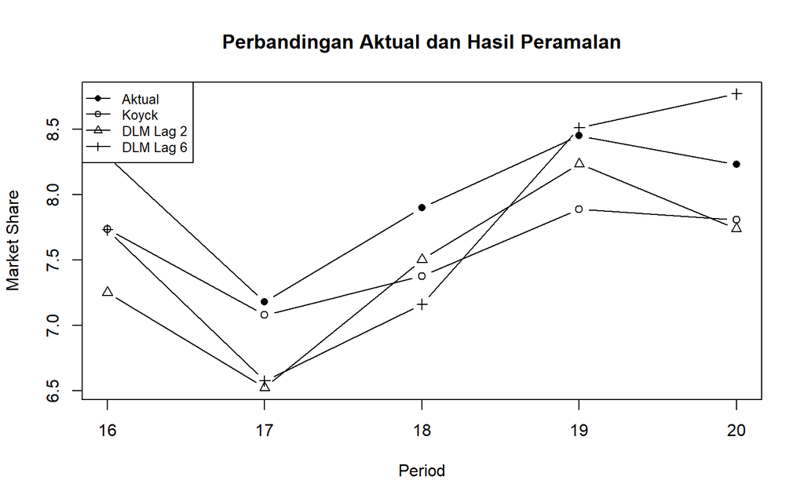

```r
plot(test1$Period, test1$MarketShare,
     type = "b", pch = 16,
     ylim = range(c(test1$MarketShare,
                    fore.koyck1$forecasts,
                    fore.dlm1$forecasts,
                    fore.dlm1.opt$forecasts)),
     xlab = "Period",
     ylab = "Market Share",
     main = "Perbandingan Aktual dan Hasil Peramalan")

lines(test1$Period, fore.koyck1$forecasts, type = "b", pch = 1)
lines(test1$Period, fore.dlm1$forecasts, type = "b", pch = 2)
lines(test1$Period, fore.dlm1.opt$forecasts, type = "b", pch = 3)

legend("topleft",
       legend = c("Aktual", "Koyck", "DLM Lag 2", paste0("DLM Lag ", q.opt1)),
       lty = 1,
       pch = c(16, 1, 2, 3),
       cex = 0.8)
```

# Latihan 2

Pada Latihan 2 akan dilakukan pemodelan ARDL menggunakan data `Sales` sebagai peubah dependen dan `Advertising` sebagai peubah independen dari tahun 1975 sampai 2014.

## Input Data

```r
data2 <- data.frame(
  Year = 1975:2014,
  Sales = c(
    11.7, 12.0, 12.3, 12.8, 13.1,
    13.6, 13.9, 14.4, 14.7, 15.3,
    15.5, 15.8, 16.1, 16.6, 16.9,
    16.7, 16.9, 17.4, 17.6, 17.9,
    18.0, 17.9, 18.0, 18.2, 18.2,
    18.3, 18.6, 19.2, 19.3, 19.5,
    19.2, 19.3, 19.5, 20.0, 20.0,
    19.9, 19.8, 19.9, 20.2, 21.0
  ),
  Advertising = c(
    9.4, 9.6, 10.0, 10.4, 10.8,
    10.9, 11.7, 12.2, 12.5, 12.9,
    13.0, 13.2, 13.8, 14.2, 14.6,
    14.4, 15.0, 15.4, 15.7, 15.9,
    15.9, 16.0, 16.3, 16.2, 16.8,
    17.3, 17.6, 18.1, 18.3, 18.5,
    18.7, 18.9, 19.2, 20.0, 20.0,
    20.3, 20.4, 21.0, 21.5, 22.1
  )
)

data2
```

```
##    Year Sales Advertising
## 1  1975  11.7         9.4
## 2  1976  12.0         9.6
## 3  1977  12.3        10.0
## 4  1978  12.8        10.4
## 5  1979  13.1        10.8
## 6  1980  13.6        10.9
## 7  1981  13.9        11.7
## 8  1982  14.4        12.2
## 9  1983  14.7        12.5
## 10 1984  15.3        12.9
## 11 1985  15.5        13.0
## 12 1986  15.8        13.2
## 13 1987  16.1        13.8
## 14 1988  16.6        14.2
```

[output cut: 26 more lines]

```r
str(data2)
```

```
## 'data.frame':    40 obs. of  3 variables:
##  $ Year       : int  1975 1976 1977 1978 1979 1980 1981 1982 1983 1984 ...
##  $ Sales      : num  11.7 12 12.3 12.8 13.1 13.6 13.9 14.4 14.7 15.3 ...
##  $ Advertising: num  9.4 9.6 10 10.4 10.8 10.9 11.7 12.2 12.5 12.9 ...
```

## Pembagian Data

Agar proporsi pembagian data sama seperti contoh pada materi, 75% observasi pertama digunakan untuk *training* dan 25% observasi terakhir untuk *testing*. Dengan 40 observasi, diperoleh 30 data *training* dan 10 data *testing*.

```r
train2 <- data2[1:30, ]
test2  <- data2[31:40, ]

train2
```

```
##    Year Sales Advertising
## 1  1975  11.7         9.4
## 2  1976  12.0         9.6
## 3  1977  12.3        10.0
## 4  1978  12.8        10.4
## 5  1979  13.1        10.8
## 6  1980  13.6        10.9
## 7  1981  13.9        11.7
## 8  1982  14.4        12.2
## 9  1983  14.7        12.5
## 10 1984  15.3        12.9
## 11 1985  15.5        13.0
## 12 1986  15.8        13.2
## 13 1987  16.1        13.8
## 14 1988  16.6        14.2
```

[output cut: 16 more lines]

```r
test2
```

```
##    Year Sales Advertising
## 31 2005  19.2        18.7
## 32 2006  19.3        18.9
## 33 2007  19.5        19.2
## 34 2008  20.0        20.0
## 35 2009  20.0        20.0
## 36 2010  19.9        20.3
## 37 2011  19.8        20.4
## 38 2012  19.9        21.0
## 39 2013  20.2        21.5
## 40 2014  21.0        22.1
```

```r
# data time series
train2.ts <- ts(train2[, c("Sales", "Advertising")], start = 1975)
test2.ts  <- ts(test2[, c("Sales", "Advertising")], start = 2005)
data2.ts  <- ts(data2[, c("Sales", "Advertising")], start = 1975)
```

## Model Autoregressive Distributed Lag (ARDL)

Model ARDL menggabungkan lag dari peubah independen dengan lag dari peubah dependen itu sendiri. Secara umum, model ARDL dengan satu peubah independen dapat ditulis sebagai

$$Y_t=\alpha+\sum_{i=0}^{p}\beta_iX_{t-i}+\sum_{j=1}^{q}\phi_jY_{t-j}+u_t.$$

Pada fungsi `ardlDlm()`, $p$ menunjukkan panjang lag peubah independen dan $q$ menunjukkan ordo autoregressive dari peubah dependen.

### Pemodelan Awal ARDL(1,1)

Sebagai model awal digunakan $p=1$ dan $q=1$, sesuai dengan contoh pada materi.

```r
model.ardl2 <- ardlDlm(
  formula = Sales ~ Advertising,
  data = train2,
  p = 1,
  q = 1
)

summary(model.ardl2)
```

```
##
## Time series regression with "ts" data:
## Start = 2, End = 30
##
## Call:
## dynlm(formula = as.formula(model.text), data = data)
##
## Residuals:
##       Min        1Q    Median        3Q       Max
## -0.229277 -0.127437  0.009143  0.109228  0.259132
##
## Coefficients:
##               Estimate Std. Error t value Pr(>|t|)
## (Intercept)    1.55786    0.44353   3.512  0.00171 **
## Advertising.t  0.29110    0.13707   2.124  0.04376 *
## Advertising.1 -0.09584    0.16067  -0.596  0.55621
## Sales.1        0.74360    0.09964   7.463 8.14e-08 ***
## ---
## Signif. codes:  0 '***' 0.001 '**' 0.01 '*' 0.05 '.' 0.1 ' ' 1
##
## Residual standard error: 0.1576 on 25 degrees of freedom
## Multiple R-squared:  0.9955, Adjusted R-squared:  0.9949
## F-statistic:  1830 on 3 and 25 DF,  p-value: < 2.2e-16
```

```r
AIC(model.ardl2)
```

```
## [1] -19.18177
```

```r
BIC(model.ardl2)
```

```
## [1] -12.34529
```

### Peramalan dan Akurasi

```r
fore.ardl2 <- forecast(
  model = model.ardl2,
  x = matrix(test2$Advertising, nrow = 1),
  h = 10
)

fore.ardl2
```

```
## $forecasts
##  [1] 19.72862 19.93768 20.16129 20.53170 20.73047 20.96560 21.14081 21.43616
##  [9] 21.74384 22.09937
##
## $call
## forecast.ardlDlm(model = model.ardl2, x = matrix(test2$Advertising,
##     nrow = 1), h = 10)
##
## attr(,"class")
## [1] "forecast.ardlDlm" "dLagM"
```

```r
mape.ardl2 <- MAPE(
  fore.ardl2$forecasts,
  test2$Sales
)

mape.ardl2
```

```
## [1] 0.0484832
```

```r
# akurasi data training
GoF(model.ardl2)
```

```
##              n       MAE           MPE        MAPE       sMAPE      MASE
## model.ardl2 29 0.1238592 -0.0001484019 0.007696613 0.007697173 0.4281553
##                   MSE     MRAE     GMRAE
## model.ardl2 0.0214047 81884782 0.7548444
```

### *Lag* Optimum

Untuk menentukan kombinasi lag ARDL terbaik digunakan fungsi `ardlBoundOrders()` dengan kriteria AIC. Pencarian dibatasi maksimum 6 lag untuk peubah independen dan dependen.

```r
model.ardl2.orders <- ardlBoundOrders(
  data = data.frame(train2[, c("Sales", "Advertising")]),
  formula = Sales ~ Advertising,
  ic = "AIC",
  max.p = 6,
  max.q = 6
)

model.ardl2.orders
```

```
## $p
##   Advertising
## 1           6
##
## $q
## [1] 1
##
## $Stat.table
##            q = 1      q = 2      q = 3     q = 4      q = 5     q = 6
## p = 1 -17.699638 -15.159785 -11.171253 -12.97933  -9.595366 -13.27011
## p = 2 -15.479841 -13.700376  -9.602500 -11.28856  -8.094541 -11.38500
## p = 3 -12.842321 -12.842321 -11.353394 -12.78397 -10.302797 -12.74830
## p = 4 -10.635346  -8.929704  -8.929704 -12.70373  -9.983369 -12.65121
## p = 5  -9.806117 -13.826706 -13.057325 -13.05733 -11.391142 -15.09657
## p = 6 -10.952036 -11.769321  -9.940426 -13.06169 -13.061688 -14.01520
##
## $min.Stat
## [1] -17.69964
```

```r
p.opt2 <- as.integer(model.ardl2.orders$p)
q.opt2 <- as.integer(model.ardl2.orders$q)
aic.opt2 <- model.ardl2.orders$min.Stat

data.frame(
  p_optimum = p.opt2,
  q_optimum = q.opt2,
  AIC = aic.opt2
)
```

```
##   p_optimum q_optimum       AIC
## 1         6         1 -17.69964
```

Selanjutnya dilakukan pemodelan menggunakan nilai $p$ dan $q$ optimum tersebut.

```r
model.ardl2.opt <- ardlDlm(
  formula = Sales ~ Advertising,
  data = train2,
  p = p.opt2,
  q = q.opt2
)

summary(model.ardl2.opt)
```

```
##
## Time series regression with "ts" data:
## Start = 7, End = 30
##
## Call:
## dynlm(formula = as.formula(model.text), data = data)
##
## Residuals:
##      Min       1Q   Median       3Q      Max
## -0.23306 -0.09151  0.01295  0.07470  0.21364
##
## Coefficients:
##               Estimate Std. Error t value Pr(>|t|)
## (Intercept)    1.32022    1.25797   1.049  0.31057
## Advertising.t  0.31570    0.17166   1.839  0.08578 .
## Advertising.1  0.12492    0.19955   0.626  0.54072
## Advertising.2 -0.18936    0.18764  -1.009  0.32890
## Advertising.3  0.07628    0.18103   0.421  0.67946
## Advertising.4 -0.17651    0.18155  -0.972  0.34635
## Advertising.5  0.30997    0.18352   1.689  0.11189
## Advertising.6 -0.27534    0.14653  -1.879  0.07981 .
## Sales.1        0.75334    0.18538   4.064  0.00102 **
## ---
## Signif. codes:  0 '***' 0.001 '**' 0.01 '*' 0.05 '.' 0.1 ' ' 1
##
## Residual standard error: 0.1517 on 15 degrees of freedom
## Multiple R-squared:  0.9939, Adjusted R-squared:  0.9906
## F-statistic: 305.5 on 8 and 15 DF,  p-value: 3.411e-15
```

```r
AIC(model.ardl2.opt)
```

```
## [1] -13.68091
```

```r
BIC(model.ardl2.opt)
```

```
## [1] -1.900375
```

### Peramalan Model ARDL Optimum

```r
fore.ardl2.opt <- forecast(
  model = model.ardl2.opt,
  x = matrix(test2$Advertising, nrow = 1),
  h = 10
)

fore.ardl2.opt
```

```
## $forecasts
##  [1] 19.77046 19.90678 20.14363 20.47851 20.76078 20.91116 21.10850 21.29897
##  [9] 21.84459 22.12829
##
## $call
## forecast.ardlDlm(model = model.ardl2.opt, x = matrix(test2$Advertising,
##     nrow = 1), h = 10)
##
## attr(,"class")
## [1] "forecast.ardlDlm" "dLagM"
```

```r
mape.ardl2.opt <- MAPE(fore.ardl2.opt$forecasts, test2$Sales)
mape.ardl2.opt
```

```
## [1] 0.04784636
```

```r
# akurasi data training
GoF(model.ardl2.opt)
```

```
##                  n        MAE           MPE        MAPE     sMAPE      MASE
## model.ardl2.opt 24 0.09873087 -6.842906e-05 0.005777138 0.0057764 0.3662597
##                        MSE     MRAE     GMRAE
## model.ardl2.opt 0.01438962 39778546 0.7183236
```

## Perbandingan Model Latihan 2

Model ARDL awal dan model ARDL dengan lag optimum dibandingkan menggunakan nilai MAPE pada data *testing*.

```r
akurasi2 <- data.frame(
  Model = c("ARDL(1,1)", paste0("ARDL(", p.opt2, ",", q.opt2, ")")),
  MAPE = c(mape.ardl2, mape.ardl2.opt)
)

akurasi2 <- akurasi2[order(akurasi2$MAPE), ]
row.names(akurasi2) <- NULL
akurasi2
```

```
##       Model       MAPE
## 1 ARDL(6,1) 0.04784636
## 2 ARDL(1,1) 0.04848320
```

```r
model.terbaik2 <- akurasi2$Model[1]
mape.terbaik2  <- akurasi2$MAPE[1]

model.terbaik2
```

```
## [1] "ARDL(6,1)"
```

```r
mape.terbaik2
```

```
## [1] 0.04784636
```

Berdasarkan nilai MAPE pada data *testing*, model terbaik untuk Latihan 2 adalah **ARDL(6,1)** dengan MAPE sebesar **0.0478**.

### Plot Perbandingan

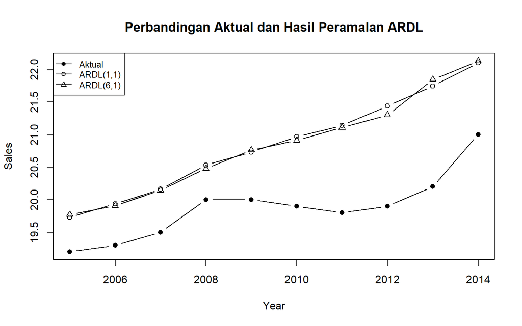

```r
plot(test2$Year, test2$Sales,
     type = "b", pch = 16,
     ylim = range(c(test2$Sales,
                    fore.ardl2$forecasts,
                    fore.ardl2.opt$forecasts)),
     xlab = "Year",
     ylab = "Sales",
     main = "Perbandingan Aktual dan Hasil Peramalan ARDL")

lines(test2$Year, fore.ardl2$forecasts, type = "b", pch = 1)
lines(test2$Year, fore.ardl2.opt$forecasts, type = "b", pch = 2)

legend("topleft",
       legend = c("Aktual", "ARDL(1,1)", paste0("ARDL(", p.opt2, ",", q.opt2, ")")),
       lty = 1,
       pch = c(16, 1, 2),
       cex = 0.8)
```

# Kesimpulan

Pada Latihan 1, model terbaik ditentukan dari model Koyck, DLM lag 2, dan DLM dengan lag optimum berdasarkan MAPE data *testing*. Model dengan nilai MAPE paling kecil adalah **Koyck**.

Pada Latihan 2, kombinasi lag ARDL optimum terlebih dahulu ditentukan menggunakan AIC, kemudian performa peramalannya dibandingkan dengan ARDL(1,1). Model dengan nilai MAPE data *testing* paling kecil adalah **ARDL(6,1)**.